# Sentiment Analysis based on Reddit Data - Code Demo

COMM408

2025-03-23

## What are we doing here?

This is a practice script (in R Markdown format) on the topic *Sentiment Analysis* (albeit based on the traditional dictionary approach). We’ll start with a code demo, accompanied by guiding questions to facilitate the learning process. This code demo will prepare you for the next coding challenges and assignments.

## Reddit Data

Use the `find_thread_urls` function in the [**RedditExtractoR**](https://rdrr.io/cran/RedditExtractoR/) package to collect subreddit data from the public Reddit API (No API key or token is needed).

```r
library(RedditExtractoR)

df <- find_thread_urls(subreddit="amherst", sort_by="top",period = "year")

save(df, file="r_reddit.rda")
```

## Clean the data

Start by loading necessary libraries and the pre-saved data `r_reddit.rda`. Note [**syuzhet**](https://cran.r-project.org/web/packages/syuzhet/vignettes/syuzhet-vignette.html/) is a library for dictionary-based sentiment ratings.

```r
library(readr)
library(ggplot2)
library(lubridate)
library(reshape2)
library(dplyr)
library(syuzhet)
library(stringr)
library(tidyr)

load(file="r_reddit.rda")
```

## Timestamps

The `date_utc` column in `df` contains the timestamps (in the YYYY-MM-DD format). Run `as.Date()` to convert them as dates.

```r
df$date_utc <- as.Date(df$date_utc)
```

## Sentiment ratings

Use `get_nrc_sentiment()` to apply the [NRC dictionaries](https://saifmohammad.com/WebPages/NRC-Emotion-Lexicon.htm) to get sentiment scores based on the `text` column.

```r
Sentiment <- get_nrc_sentiment(df$text)
```

The newly created `Sentiment` dataframe contains ratings along 8 unique sentiments (*anger*, *anticipation*, *disgust*, *fear*, *joy*, *sadness*, *surprise*, *trust*) and the generic *negative* and *positive* scores. However, `Sentiment` does not contain the text content and other metadata from the original `df`. So, in the next step, we use `cbind()` to combine `Sentiment` and `df` into a new dataframe `all_senti`.

```r
all_senti <- cbind(df, Sentiment)
```

Sidenote: The [**syuzhet**](https://cran.r-project.org/web/packages/syuzhet/vignettes/syuzhet-vignette.html/) library has different in-built dictionaries, and NRC is one of them. If you want to try other dictionaries, such as [bing](https://www.cs.uic.edu/~liub/FBS/sentiment-analysis.html), [afinn](http://corpustext.com/reference/sentiment_afinn.html#:~:text=The%20AFINN%20lexicon%20is%20a,but%20they%20are%20excluded%20here.),and [stanford](https://nlp.stanford.edu/sentiment/) dictionaries, try:

> Sentiment <- get_sentiment(instagram_posts$Description, method = “nrc”)

> Sentiment <- get_sentiment(instagram_posts$Description, method = “afinn”)

## Questions for you

**Question 1: What is the most ‘joyful’ text in the dataset?**

**Question 2: What is the ‘saddest’ text in the dataset?**

**Question 3: Do you think the sentiment ratings reflect the ground truth?**

## Daily averages by sentiment types

In the following code chunk, we will aggregate the scores of different sentiment types by dates so that we can plot out how different sentiments fluctuate over time. The new dataframe is called `senti_aggregated` containing daily averages by the 8 distinct sentiment types

```r
all_senti$date_label <- as.factor(all_senti$date_utc)  #create a new column called date_label to store the date info as a factor

senti_aggregated <- all_senti %>%
  group_by(date_label) %>%
  summarise(anger = mean(anger),
            anticipation = mean(anticipation),
            disgust = mean(disgust),
            fear = mean(fear),
            joy = mean(joy),
            sadness = mean(sadness),
            surprise = mean(surprise),
            trust = mean(trust))

senti_aggregated <- senti_aggregated %>% pivot_longer(cols = -c(date_label), names_to = "variable", values_to = "value") #convert to long form
```

## Plotting daily averages by sentiment types

Use `ggplot2` to create a static plot applying the `FiveThirtyEight` theme.

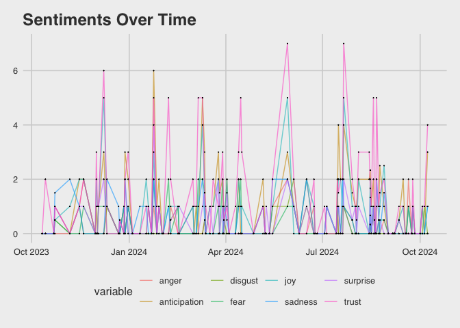

```r
library(ggplot2)
library(ggthemes)

senti_aggregated$date_label <- as.Date(senti_aggregated$date_label)

ggplot(data = senti_aggregated, aes(x = date_label, y = value,group = variable)) +
  geom_line(size = 0.5, alpha = 0.6, aes(color = variable)) +
  geom_point(size = 0) +
  ylim(0, NA) +
  theme(legend.title=element_blank(), axis.title.x = element_blank()) +
  ylab("Average sentiment score") +
  ggtitle("Sentiments Over Time")+
  theme_fivethirtyeight(base_size = 12, base_family = "sans")
```

Use `highcharter` to create an interactive plot.

```r
library(highcharter)

title <- paste0("sentiment scores over time", Sys.Date())
highchart() %>%
  hc_add_series(senti_aggregated,"line", hcaes(x = date_label, y = value, group=variable)) %>%
  hc_xAxis(type = "datetime")
```

[interactive chart not shown]